# MAT_502_Final

chen

October 1, 2016

# **HollywoodMovies2011**

# Introduction

Information for 136 movies released from Hollywood in 2011, dataset with 136 observations on the 14 variables

# Data description

`Movie` Title of movie

`LeadStudio` Studio that released the movie

`RottenTomatoes` Rotten Tomatoes rating

`AudienceScore` Audience rating

`Story` General theme - one of 21 themes

`Genre` Type of movie: Action, Adventure, Animation, Comedy, Drama, Fantasy, Horror, Romance, or Thriller

`TheatersOpenWeek` Number of screens for opening weekend

`BOAverageOpenWeek` Average box office income per theater - opening weekend

`DomesticGross` Gross income for domestic viewers

`ForeignGross` Gross income for foreign viewers

`WorldGross` Gross income for all viewers

`Budget` Productoin budge

`rofitability` WorldGross/Budget

`openingWeekend` Opening weekend gross

# **Exploratory Data Analysis (EDA)**

To read the `.csv` file and store it in movie.

```r
movie<-read.csv(file="C:\\Users\\Simon_000\\Downloads\\HollywoodMovies2011.csv")
```

Show the first six row of the file.

```r
head(movie)
```

```
##                                         Movie       LeadStudio
## 1                                   Insidious             Sony
## 2                       Paranormal Activity 3      Independent
## 3                                 Bad Teacher      Independent
## 4 Harry Potter and the Deathly Hallows Part 2      Warner Bros
## 5                                 Bridesmaids Relativity Media
## 6                           Midnight in Paris             Sony
##   RottenTomatoes AudienceScore         Story   Genre TheatersOpenWeek
## 1             67            65 Monster Force  Horror             2408
## 2             68            58 Monster Force  Horror             3321
## 3             44            38        Comedy  Comedy             3049
## 4             96            92       Rivalry Fantasy             4375
## 5             90            77       Rivalry  Comedy             2918
## 6             93            84          Love Romance              944
##   BOAverageOpenWeek DomesticGross ForeignGross WorldGross Budget
## 1              5511         54.01        43.00     97.009    1.5
## 2             15829        103.66        98.24    201.897    5.0
## 3             10365        100.29       115.90    216.196   20.0
## 4             38672        381.01       947.10   1328.111  125.0
## 5              8995        169.11       119.28    288.382   32.5
## 6              6177         56.18        83.00    139.177   17.0
##   Profitability OpeningWeekend
## 1     64.672667          13.27
## 2     40.379400          52.57
## 3     10.809800          31.60
## 4     10.624888         169.19
## 5      8.873292          26.25
## 6      8.186882           5.83
```

summary the statistical properties of each attribute. shaow the mean, median, min, max for each attribute.

```r
summary(movie)
```

```
##                                Movie                LeadStudio
##  30 Minutes or Less               :  1   Independent     :32
##  50/50                            :  1   Warner Bros     :12
##  A Dangerous Method               :  1   20th Century Fox: 9
##  A Very Harold and Kumar Christmas:  1   Universal       : 9
##  Abduction                        :  1   Disney          : 8
##  Anonymous                        :  1   Relativity Media: 8
##  (Other)                          :130   (Other)         :58
##  RottenTomatoes  AudienceScore            Story          Genre
##  Min.   : 4.00   Min.   :24.0   Monster Force:19   Action   :32
##  1st Qu.:29.25   1st Qu.:49.5   Comedy       :14   Comedy   :27
##  Median :53.50   Median :61.0   Quest        :13   Drama    :21
##  Mean   :53.19   Mean   :61.6   Love         :12   Horror   :17
##  3rd Qu.:78.00   3rd Qu.:76.5   Discovery    :11   Thriller :13
##  Max.   :97.00   Max.   :93.0   Rivalry      :10   Animation:12
##  NA's   :2       NA's   :1      (Other)      :57   (Other)  :14
##  TheatersOpenWeek BOAverageOpenWeek DomesticGross     ForeignGross
##  Min.   :   3     Min.   : 1513     Min.   :  0.02   Min.   :  0.24
##  1st Qu.:2550     1st Qu.: 3779     1st Qu.: 19.03   1st Qu.: 14.25
##  Median :2995     Median : 5686     Median : 37.35   Median : 47.00
##  Mean   :2828     Mean   : 8339     Mean   : 63.22   Mean   : 96.92
##  3rd Qu.:3400     3rd Qu.: 8923     3rd Qu.: 80.46   3rd Qu.:102.00
##  Max.   :4375     Max.   :93230     Max.   :381.01   Max.   :947.10
##  NA's   :16       NA's   :16        NA's   :2        NA's   :15
##    WorldGross           Budget       Profitability    OpeningWeekend
##  Min.   :   0.025   Min.   :  0.20   Min.   : 0.000   Min.   :  0.00
##  1st Qu.:  30.706   1st Qu.: 20.25   1st Qu.: 1.065   1st Qu.:  7.71
##  Median :  76.659   Median : 36.50   Median : 2.199   Median : 13.10
##  Mean   : 150.742   Mean   : 53.48   Mean   : 3.315   Mean   : 20.34
##  3rd Qu.: 173.691   3rd Qu.: 70.00   3rd Qu.: 3.667   3rd Qu.: 25.00
##  Max.   :1328.111   Max.   :250.00   Max.   :64.673   Max.   :169.19
##  NA's   :2          NA's   :2        NA's   :2        NA's   :3
```

create the histograms for the `AudienceScore`, set color as red.

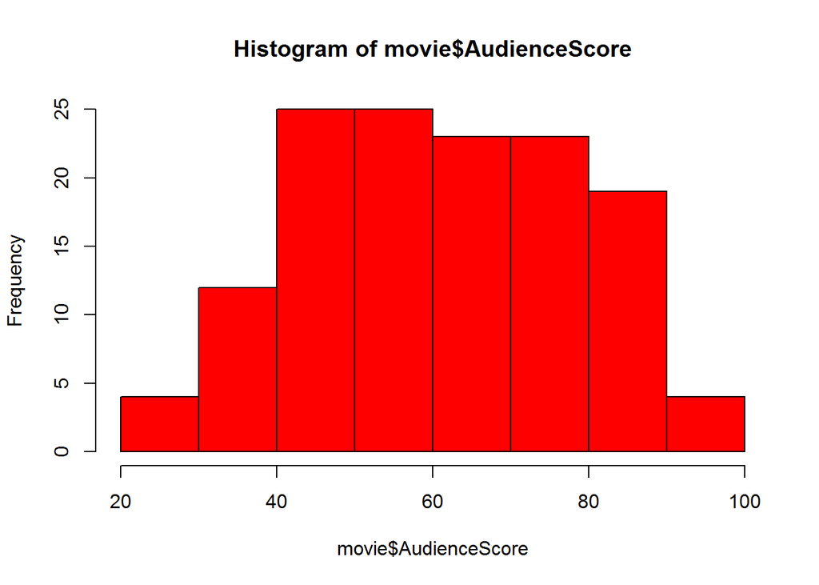

```r
hist(movie$AudienceScore, col = "red")
```

use the scatter plot to plot `AudienceScore` and `Budget`.We can see the relationship. A scatter plot display values for typically two variables for a set of data. The data is displayed as a collection of points, each having the value of one variable determining the position on the horizontal axis and the value of the other variable determining the position on the vertical axis.

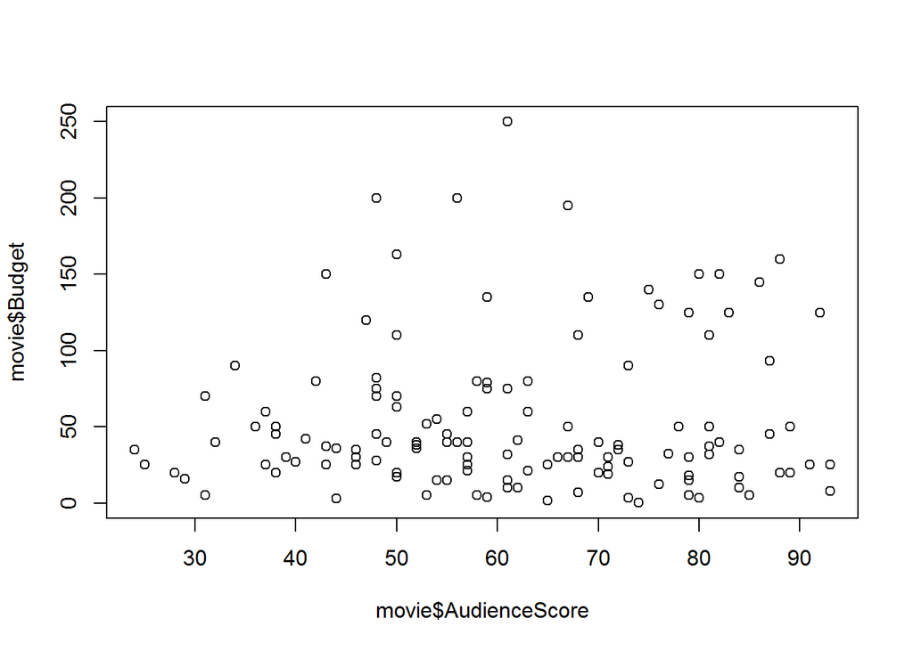

```r
plot(movie$AudienceScore,movie$Budget)
```

# Box Plot

A box plot of select attribute of the `HollywoodMoves2011` dataset. The box plot is a way of displaying the distribution of data based on the five number summary: minimum, first quartile, median, third quartile, and maximum. The first quartile (Q1) is defined as the middle number between the smallest number and the median of the data set. The second quartile (Q2) is the median of the data. The third quartile (Q3) is the middle value between the median and the highest value of the data set.

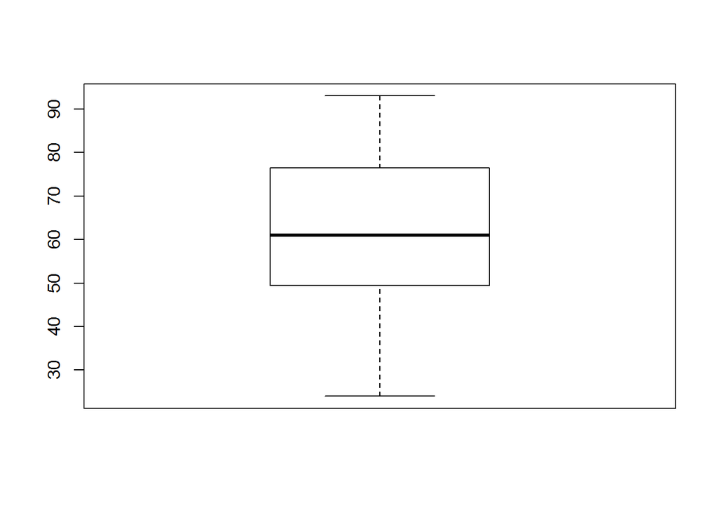

```r
boxplot(movie$AudienceScore)
```

computing the mean for the `AudienceScore` and `Budget` value.

```r
means<- round(tapply(movie$AudienceScore, movie$Budget, mean), digits=2)
means
```

```
##   0.2   1.5     3   3.2   3.5     4     5     7     8    10  12.5    15
## 74.00 65.00 44.00 80.00 73.00 59.00 59.83 68.00 93.00 69.00 76.00 62.25
##    16    17    18    19    20    21    24    25    27    28    30    32
## 29.00 67.00 79.00 71.00 59.00 60.00 71.00 57.12 56.50 48.00 61.62 71.00
##  32.5    35    36    37    38    40    41    42    45  49.9    50  50.2
## 77.00    NA 48.00 62.00 62.00 56.44 62.00 41.00 57.00 36.00 71.50 67.00
##    52    55    60    63    70    75    79    80    82    90    93   110
## 53.00 54.00 52.33 50.00 43.00 56.00 59.00 54.33 48.00 53.50 87.00 66.33
##   120   125   130   135   140   145   150   160   163   195   200   250
## 47.00 84.67 76.00 64.00 75.00 86.00 71.25 88.00 50.00 67.00 52.00 61.00
```

plot the graph that compare two value between `AudienceScore` and `Budget`.

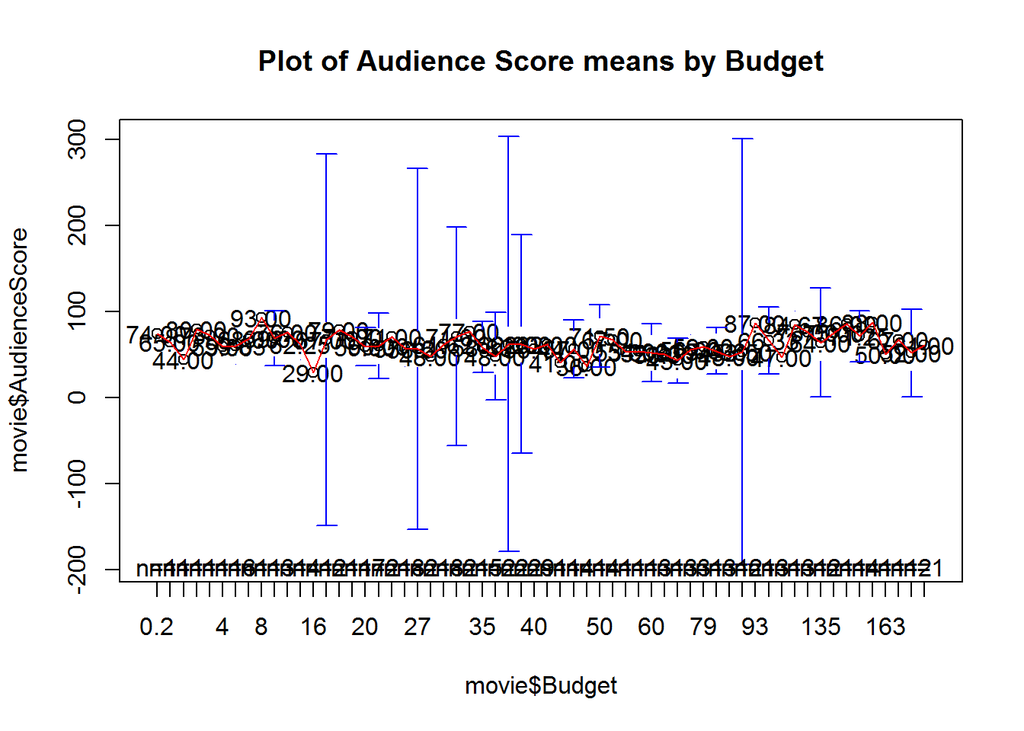

```r
library(gplots)  #load the "gplots" package to plot means
plotmeans(movie$AudienceScore~movie$Budget, digits=2, ccol="red", mean.labels=T, main="Plot of Audience Score means by Budget")
```

plot the `boxplot` that compare two value between `AudienceScore` and `Budget`.

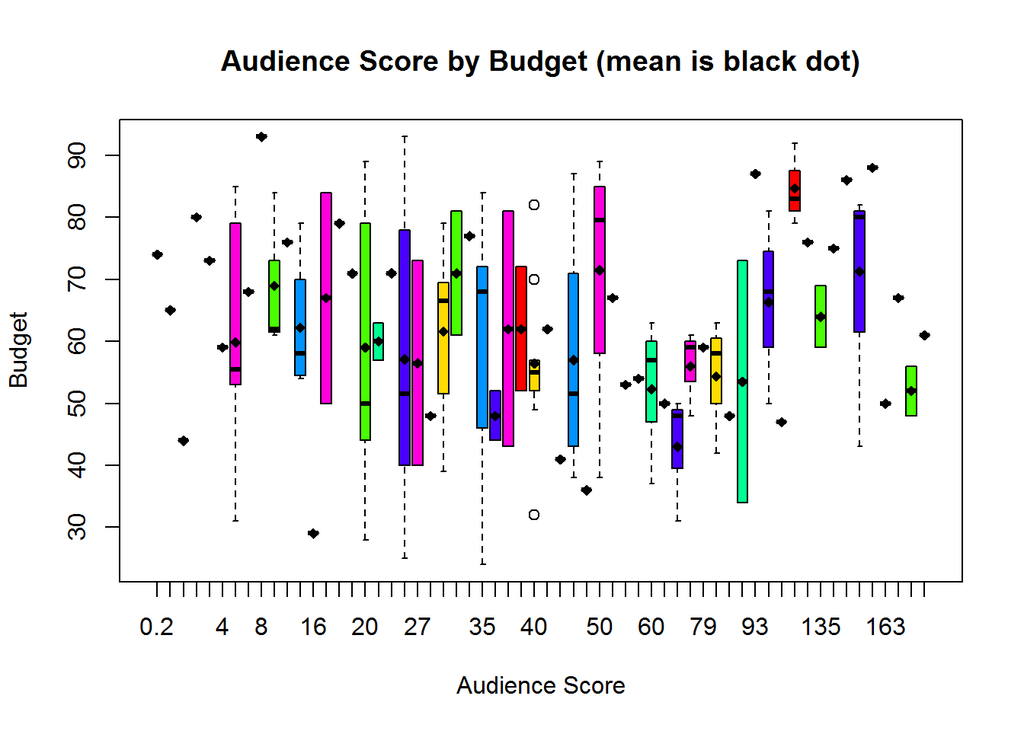

```r
boxplot(movie$AudienceScore ~ movie$Budget, main="Audience Score by Budget (mean is black dot)", xlab="Audience Score", ylab="Budget", col=rainbow(7))
points(means, col="black", pch=18)
```

# Pie Charts

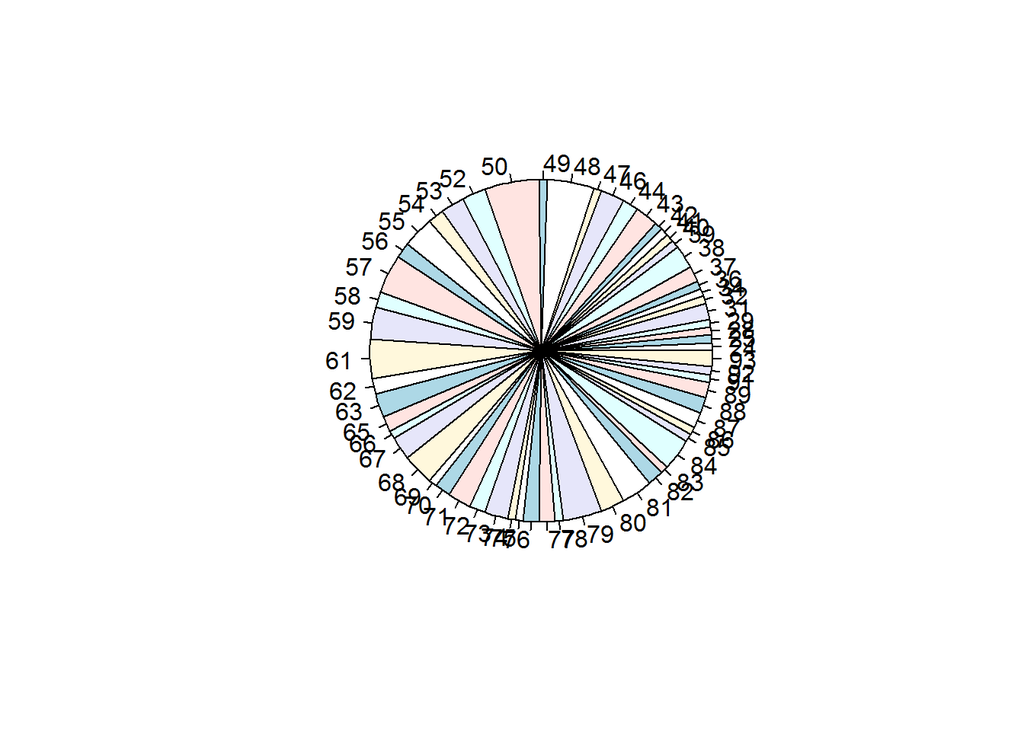

```r
pie(table(movie$AudienceScore))
```

# Variance

variance of `AudienceScore`

```r
var(movie$AudienceScore)
```

```
## [1] NA
```